# Fit length ditributions_Tromsøflaket

Muriel Dunn

2022-03-31

```r
library(fitdistrplus)
require(actuar)
require(gamlss.dist)
```

## Fitting the distributions

I want to find the best fit for the length measurements I have from the multinet and tucker trawl data. A represenattive length distribution will inform and constrain the model input possibilities.

```r
# Multinet
x_Euphausiaceafurcilia = c(2.5,2.5,2.5,3,3,3,3,3.5,3.5,3.5,3.5,3.5,4,4,4,4,4,4.5,4.5,2.5,3,3.5,4,3,3.5,4,4.5,4,4,4.5,3.5,2.5,2.5,2.5,3,3,3,3,3,4,4.5,4.5,4.5,2.5,3,3.5,3.5,4.5,4.5,3,4.5,4.5,2.5,2.5,4,4,4,2,2.5,3,4,4.5,3,3,3.5,3,3.5,3.5,4,4.5,3.5,4,4,4.5,4.5,4.5,4.5,5,5.5,5,6,5,5.8,6.7,5.8,5.7,5.2,5,5,5,5,5,5,5.5,5.5,5.5,6,5,5,5,5,5.5,7,5,5) #mm

# Lengths from tucker trawl
x_Thyssanoessainermis = c(6.6,3.9,4.0,3.9,3.6,5.2,6.2,3.0,4.1,5.2,4.5,3.0,4.3,4.5,5.3,3.3,4.2,4.7,4.6,3.9,4.5,4.4,4.2,6.5,3.4,4.9,5.1,5.7,4.3,2.6,3.8,4.9,3.8,4.1,3.1,4.2,4.5,5.5,3.2,3.9,4.6,4.4,3.9,3.8,3.5,3.6,3.4,4.3,3.1,2.7,4.8,3.4,2.3,5.9,4.2,4.5,3.2,3.7,5.8,5.2,4.4,4.3,6.4,4.7,4.4,3.0,4.9,4.3,4.2,5.5,3.9,4.3,4.2,4.4,5.1,4.3,4.3,5.1,10.2,4.1,6.1,4.9,7.9,4.1,6.4,3.2,11.0,10.2,7.5,4.1,4.2,9.2,3.8,4.5,6.9,3.5,3.2,4.5,5.1,7.4,3.3,4.4,5.2,4.8,3.6,9.6,3.4,4.6) #mm

x_Themistoabyssorum_MN = c(3,3,3.5,4.5,4.5,3,3.5,4,4,4,4,2,2.5,3,3.5,4,4,4,4.5,4.5,2,2.5,3,3.5,3.5,3.5,4.5,3,2,2,2.5,3,4,4,4,4,4,4.5,4.5,6.5,6.5,6.3,5.7,7.5,5,5.9,5,5.5,5.5,5,5,5,6.5,6.5,8,5,5,5,5.5,6,5,5,5,5,5.5,5.5,5.5,6,6.5,8,9,5,5,5,5)

x_Themistoabyssorum_TT = c(5.0,2.1,4.2,4.5,2.1,4.1,3.0,5.5,2.0,2.0,4.2,3.4,3.9,3.2,3.6,4.1,4.8,2.7,4.5,4.7,3.3,3.5,3.9,4.3,3.2,5.1,3.3,5.3,3.8,3.5,4.7,3.0,2.5,2.7,3.7,5.3,5.0,5.8,5.7,4.1,5.7,5.3,4.1,5.0,3.0,2.3,2.6,3.4,2.0,2.1,3.5,4.6,2.3,2.9,6.1,4.6,5.9,3.9,4.9,6.4,4.5,5.9,4.3,5.9,5.8,4.7,5.0,3.8,5.9,4.1,7.6,6.1,4.1,5.7,6.1,5.2,5.3,5.2,4.1,3.2,3.8,4.3,5.7,5.9,5.3,3.2,4.7,4.4,4.9,5.1,3.1,3.5,6.4,4.9,6.0,6.2,6.1,5.7,3.2,4.3,5.5,5.4,4.9,3.3,4.5,2.3,2.1,3.2)

x_Limacina_TT = c(1.5,1.1,1.6,0.9,1.6,1.4,1.1,1.6,1.7,0.8,1.4,1.5,1.3,1.5,1.7,1.4,1.5,1.4,1.4,1.2,1.5,0.9,1.5,1.0,1.3,0.9,1.4,1.7,1.3,0.9,1.5,1.6,1.7,1.3,1.5,1.1,0.7,1.3,0.8,1.2,1.0,1.2,1.0,0.9,1.4,1.7,1.0,1.1,1.7,1.1,1.1,0.9,1.2,1.4,1.6,1.0,0.8,1.0,1.1,1.6,1.3,1.3,1.2,0.8,1.5,1.1,0.9,0.9,0.7,1.0,0.8,1.0)# mm
x_Limacina_MN = c(0.8,2.7,0.7,2.5,1.5,1.7,1.7,1,1.1,1.1,1.3,1.3,1.3,1.4,1.5,1.5,1.7,1.7,1.7,1.8,1.8,1.8,1.8,1.8,1.9,1.9,2,2,2.1,2.2,2.3,2.4,2.4,2.5,2.5,2.5,2.6,2.6,2.6,2.7,2.7,2.7,2.7,2.8,2.8,2.9,3.3,0.9,1.2,0.6,0.6,0.6,2,1,1,0.8,0.8,1.1,1.8,1.2,1.6,1.9,1.7,1.5,1.1,2,0.9,1,1.5,1.3,0.9,0.7,1.8,1.9,0.8,1.3,0.9,0.6,0.6,0.5,0.7,0.7,0.7,0.8,0.9,1.2,1.4,2.2,1.4,1,1,1,1,1.3,0.9,0.9,0.9,1.1,1.1,1.4,1.8,2.8,2,2,2.5,1.7,1.7,1.9,0.7,0.9,1.1,2.2,2.2,1,1,1.2,1.2,1.2,1.4,2.2,2.3,1.4,1.3,1,1,1.7,1.5,2.4,1,1.7,0.9,1,1,1,1.3,1.1,1.1,0.7,0.7,0.7,2.1,1,1.2,0.9,0.9,2.1,1.5,1.5,1,1,1.3,1.4,1.8,1.2,1.4,2.3,0.8) #mm

x_Limacinewidth=c(x_Limacina_MN,x_Limacina_TT)/1.5 # Limacina L/a=1.5 Stanton 2000. For v-e model orientation is not included. Must be included as range of radius. #mm

x_fishlarvae_MN = c(8.7, 8.5, 22, 4, 6, 5.5, 6, 5.5)

x_cod_TT = c(0.76,1.82,0.95,1.51,1.5,1.48,1.35,0.95,0.85,1.2,0.75,0.75,0.62,1.31,0.75,0.65,0.76,1.5,0.56,1.0,0.93,0.63,0.67,0.52,0.64,1.2,0.82,0.68,0.61,0.82,0.6,0.76,0.72,0.83,0.91,0.93,0.75,0.82,1.23,0.69,0.76,0.73,0.83,0.63,0.65,0.81,0.71,1.62,1.58,0.91,1.11,0.87,0.99,1.3,0.61,1.57,0.8,0.71,1.11,0.72,0.75)*10 # Only my Tucker Trawl measurements #(cm*10)mm

x_codR3_L = c(0.5, 1.68, 0.71, 1.34, 1.33, 1.3 , 1.16, 0.71, 0.6 , 0.99, 0.49,
       0.49, 0.34, 1.11, 0.49, 0.37, 0.5 , 1.33, 0.27, 0.77, 0.69, 0.35,
       0.4 , 0.23, 0.36, 0.99, 0.56, 0.41, 0.33, 0.56, 0.32, 0.5 , 0.45,
       0.58, 0.66, 0.69, 0.49, 0.56, 1.02, 0.42, 0.5 , 0.46, 0.58, 0.35,
       0.37, 0.55, 0.44, 1.46, 1.42, 0.66, 0.89, 0.62, 0.75, 1.1 , 0.33,
       1.4 , 0.54, 0.44, 0.89, 0.45, 0.21) #mm length of swimbladder for total length acoustic calculation

x_codR3 = c(0.25,0.84,0.35,0.67,0.66,0.65,0.58 ,0.35 ,0.3  ,0.49 ,0.24 ,0.24 ,0.17,0.56,0.24 ,0.19 ,0.25 ,0.66 ,0.14 ,0.38 ,0.34 ,0.18 ,0.2  ,0.11 ,0.18 ,0.49 ,0.28 ,0.2,0.16 ,0.28 ,0.16 ,0.25 ,0.23 ,0.29,0.33,0.34,0.24,0.28,0.51,0.21,0.25 ,0.23,0.29 ,0.18 ,0.19 ,0.28 ,0.22 ,0.73 ,0.71 ,0.33 ,0.44 ,0.31,0.38,0.55,0.16 ,0.7,0.27,0.22 ,0.44 ,0.23 ,0.1  ,0.17 ,0.3,0.19 ,0.26 ,0.26 ,0.26 ,0.24,0.19 ,0.18,0.22 ,0.16 ,0.16 ,0.15 ,0.24 ,0.16 ,0.15 ,0.17 ,0.26,0.14 ,0.2,0.19 ,0.15 ,0.15,0.13,0.15,0.22 ,0.17 ,0.16 ,0.15 ,0.17 ,0.14,0.17 ,0.16 ,0.17 ,0.18 ,0.19 ,0.16,0.17,0.23 ,0.16 ,0.17,0.16,0.17,0.15,0.15 ,0.17,0.16 ,0.27 ,0.27 ,0.18 ,0.21,0.18 ,0.19 ,0.23 ,0.15 ,0.27 ,0.17 ,0.16 ,0.21 ,0.16,0.13) # Lengths and associated widths of swimbladder calculated from Tucker Trawl length measurements

x_codR2 = c(3.8,9.1,4.75 ,7.55 ,7.5  ,7.4 ,6.75 ,4.75 ,4.25 ,6.0,3.75 ,3.75 ,3.1,6.55,3.75 ,3.25 ,3.8,7.5,2.8,5.0,4.65 ,3.15 ,3.35,2.6,3.2,6.0,4.1,3.4,3.05,4.1,3.0,3.8,3.6 ,4.15,4.55,4.65,3.75 ,4.1,6.15,3.45,3.8,3.65,4.15 ,3.15 ,3.25,4.05 ,3.55,8.1,7.9 ,4.55,5.55,4.35 ,4.95,6.5,3.05 ,7.85,4.9,3.55,5.55,3.6,2.5,0.31,0.84 ,0.40,0.69,0.68,0.67,0.6,0.4,0.35,0.53,0.30,0.30,0.24 ,0.58 ,0.30,0.25 ,0.31,0.68,0.21,0.43,0.39,0.24,0.26,0.19,0.25,0.53,0.34 ,0.27 ,0.23 ,0.34 ,0.23,0.31 ,0.29 ,0.34,0.38 ,0.39,0.30,0.34 ,0.54,0.27 ,0.31 ,0.29 ,0.34 ,0.24 ,0.25,0.33 ,0.28 ,0.74 ,0.72 ,0.38 ,0.48,0.36 ,0.42,0.58,0.23,0.72,0.33,0.28,0.48,0.29,0.18) # Lengths and associated widths from Tucker Trawl length measurements # mm

x_codLength = c(3.8,9.1,4.75 ,7.55 ,7.5  ,7.4 ,6.75 ,4.75 ,4.25 ,6.0,3.75 ,3.75 ,3.1,6.55,3.75 ,3.25 ,3.8,7.5,2.8,5.0,4.65 ,3.15 ,3.35,2.6,3.2,6.0,4.1,3.4,3.05,4.1,3.0,3.8,3.6 ,4.15,4.55,4.65,3.75 ,4.1,6.15,3.45,3.8,3.65,4.15 ,3.15 ,3.25,4.05 ,3.55,8.1,7.9 ,4.55,5.55,4.35 ,4.95,6.5,3.05 ,7.85,4.9,3.55,5.55,3.6,2.5,0.31,0.84 ,0.40,0.69,0.68,0.67,0.6,0.4,0.35,0.53,0.30,0.30,0.24 ,0.58 ,0.30,0.25 ,0.31,0.68,0.21,0.43,0.39,0.24,0.26,0.19,0.25,0.53,0.34 ,0.27 ,0.23 ,0.34 ,0.23,0.31 ,0.29 ,0.34,0.38 ,0.39,0.30,0.34 ,0.54,0.27 ,0.31 ,0.29 ,0.34 ,0.24 ,0.25,0.33 ,0.28 ,0.74 ,0.72 ,0.38 ,0.48,0.36 ,0.42,0.58,0.23,0.72,0.33,0.28,0.48,0.29,0.18)*2 # Lengths and associated widths from Tucker Trawl length measurements # mm
```

## Euphausiacea furcilia - Multinet Krill

Length data from multi-net measurements by professional. Selected data from Stations 7-17 and < 100 m.

```r
krill_dist = fitdist(c(x_Euphausiaceafurcilia), "gamma")
length(x_Euphausiaceafurcilia)
```

```
## [1] 105
```

```r
mean(x_Euphausiaceafurcilia)
```

```
## [1] 4.044762
```

```r
sd(x_Euphausiaceafurcilia)
```

```
## [1] 1.049907
```

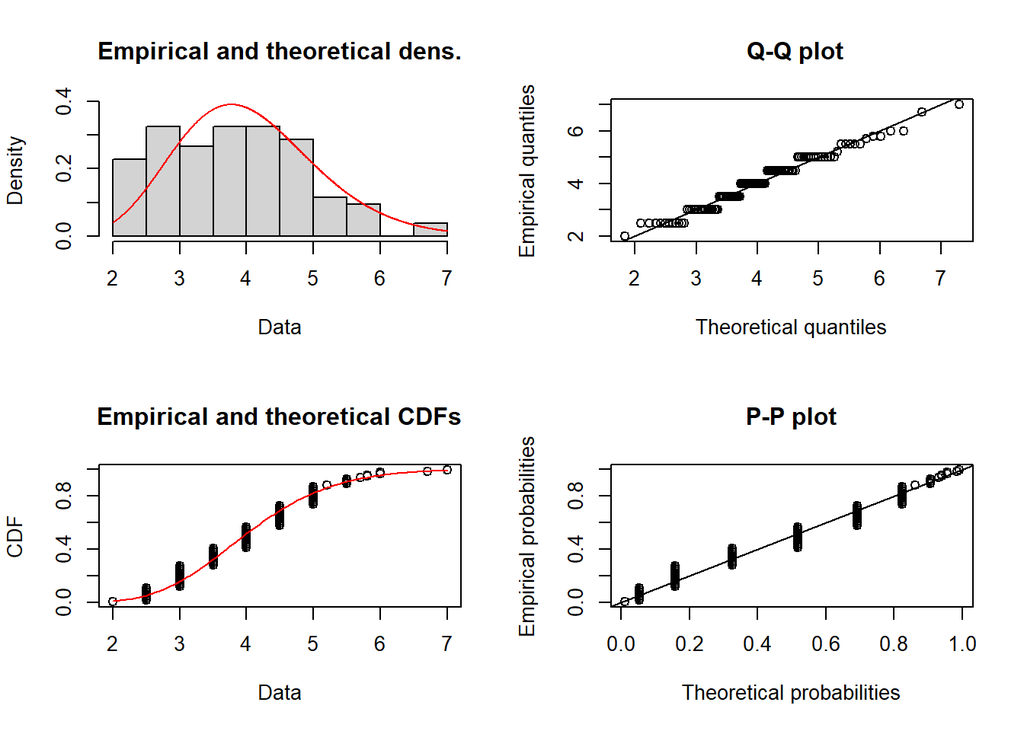

```r
plot(krill_dist)
```

```r
summary(krill_dist)
```

```
## Fitting of the distribution ' gamma ' by maximum likelihood
## Parameters :
##        estimate Std. Error
## shape 14.732153  2.0106298
## rate   3.642196  0.5056357
## Loglikelihood:  -152.0749   AIC:  308.1499   BIC:  313.4578
## Correlation matrix:
##           shape      rate
## shape 1.0000000 0.9830857
## rate  0.9830857 1.0000000
```

## Thyssanoessa inermis - Tucker krill

Measurements from Tucker Trawl length measurements spreadsheet, A log ormal distribution is the best fit I have found

```r
KrillBig_dist = fitdist(x_Thyssanoessainermis, "lnorm")
length(x_Thyssanoessainermis)
```

```
## [1] 108
```

```r
mean(x_Thyssanoessainermis)
```

```
## [1] 4.699074
```

```r
sd(x_Thyssanoessainermis)
```

```
## [1] 1.57969
```

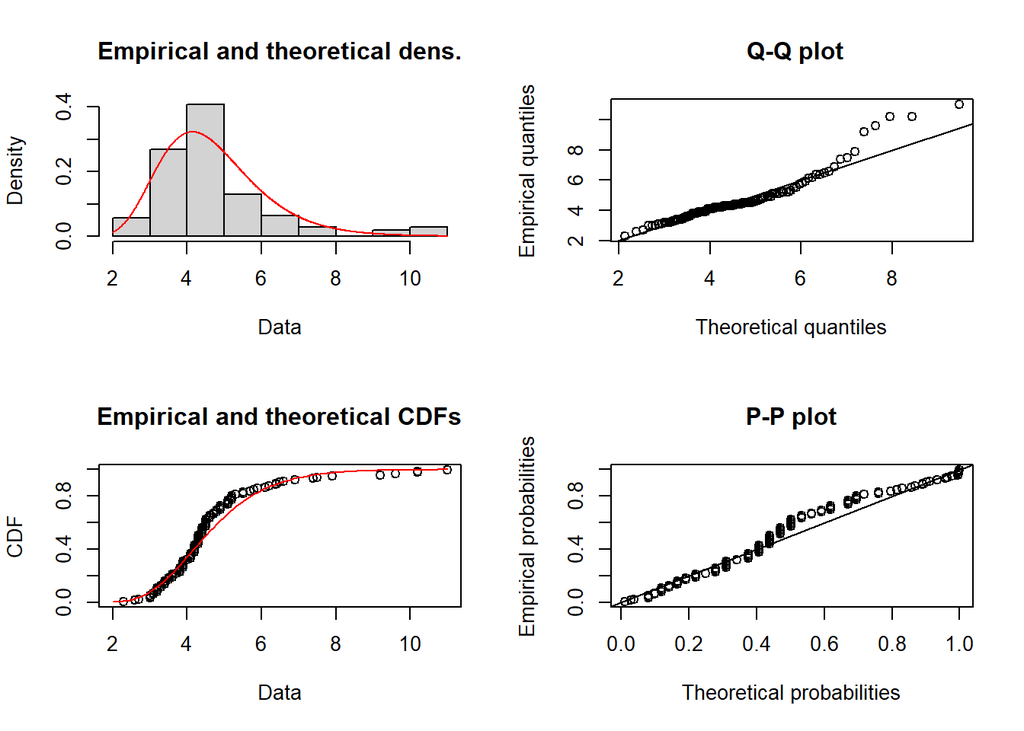

```r
plot(KrillBig_dist)
```

```r
summary(KrillBig_dist)
```

```
## Fitting of the distribution ' lnorm ' by maximum likelihood
## Parameters :
##          estimate Std. Error
## meanlog 1.5026347 0.02756483
## sdlog   0.2864621 0.01949021
## Loglikelihood:  -180.5138   AIC:  365.0276   BIC:  370.3919
## Correlation matrix:
##         meanlog sdlog
## meanlog       1     0
## sdlog         0     1
```

## Themisto Abuysorum

My measurements are from 3 stations. Gamma distributions ok for most measurements. Not very representative for the larger individuals. I was not able to identify smaller species so I likely only measured the larger ones… i think too much bias to use my data. I combined my data with the multi-net measurements done by a professional. The data from the multinet has avoidance issues and is likely biased.

```r
amphi_dist = fitdist(c(x_Themistoabyssorum_TT, x_Themistoabyssorum_MN), "gamma")
length(c(x_Themistoabyssorum_TT, x_Themistoabyssorum_MN))
```

```
## [1] 183
```

```r
mean(c(x_Themistoabyssorum_TT, x_Themistoabyssorum_MN))
```

```
## [1] 4.432787
```

```r
sd(c(x_Themistoabyssorum_TT, x_Themistoabyssorum_MN))
```

```
## [1] 1.338449
```

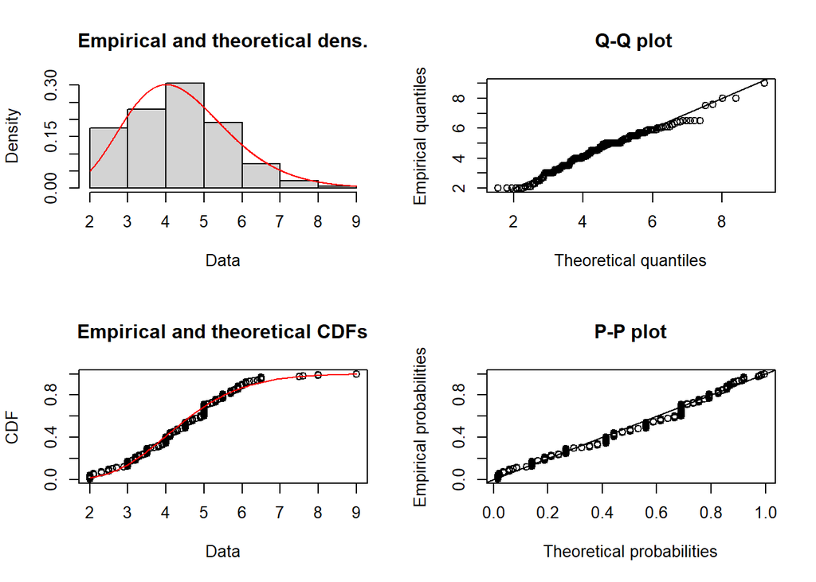

```r
plot(amphi_dist)
```

```r
summary(amphi_dist)
```

```
## Fitting of the distribution ' gamma ' by maximum likelihood
## Parameters :
##        estimate Std. Error
## shape 10.331330  1.0630698
## rate   2.330616  0.2457319
## Loglikelihood:  -312.4446   AIC:  628.8892   BIC:  635.3081
## Correlation matrix:
##           shape      rate
## shape 1.0000000 0.9759208
## rate  0.9759208 1.0000000
```

## Themisto Abuysorum - Multinet

Multinet only

```r
amphi_dist = fitdist( x_Themistoabyssorum_MN, "gamma")
length( x_Themistoabyssorum_MN)
```

```
## [1] 75
```

```r
mean( x_Themistoabyssorum_MN)
```

```
## [1] 4.598667
```

```r
sd(x_Themistoabyssorum_MN)
```

```
## [1] 1.451513
```

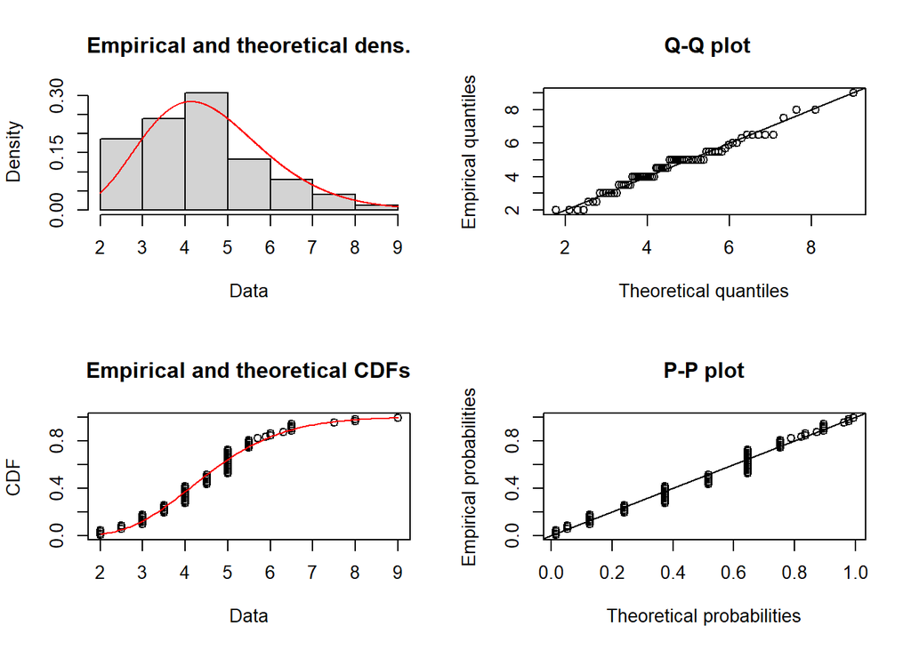

```r
plot(amphi_dist)
```

```r
summary(amphi_dist)
```

```
## Fitting of the distribution ' gamma ' by maximum likelihood
## Parameters :
##       estimate Std. Error
## shape 9.800666  1.5739494
## rate  2.131109  0.3511584
## Loglikelihood:  -132.6426   AIC:  269.2851   BIC:  273.9201
## Correlation matrix:
##           shape      rate
## shape 1.0000000 0.9746252
## rate  0.9746252 1.0000000
```

## Themisto Abuysorum - Tucker Trawl

Tucker Trawl only

```r
amphi_dist = fitdist(x_Themistoabyssorum_TT, "gamma")
length(x_Themistoabyssorum_TT)
```

```
## [1] 108
```

```r
mean(x_Themistoabyssorum_TT)
```

```
## [1] 4.317593
```

```r
sd(x_Themistoabyssorum_TT)
```

```
## [1] 1.247939
```

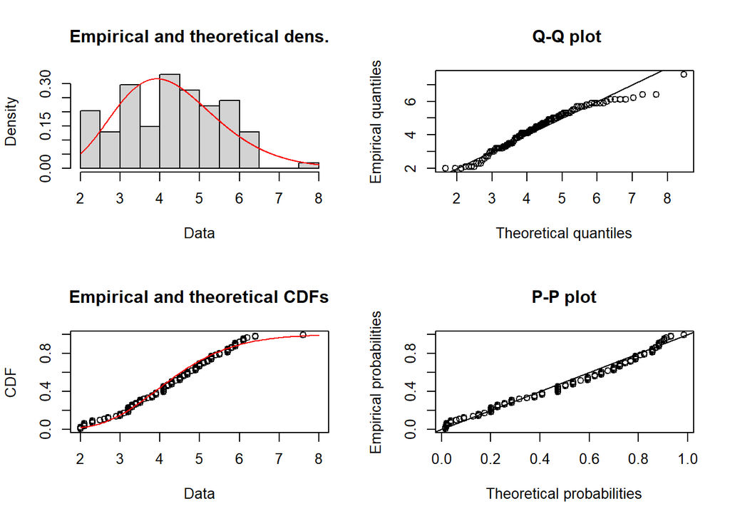

```r
plot(amphi_dist)
```

```r
summary(amphi_dist)
```

```
## Fitting of the distribution ' gamma ' by maximum likelihood
## Parameters :
##        estimate Std. Error
## shape 10.920630  1.4639683
## rate   2.529418  0.3469886
## Loglikelihood:  -178.7505   AIC:  361.5011   BIC:  366.8653
## Correlation matrix:
##           shape      rate
## shape 1.0000000 0.9772131
## rate  0.9772131 1.0000000
```

## Limacina - Multinet

```r
Lima_dist = fitdist(x_Limacina_MN, "gamma")
length(x_Limacina_MN)
```

```
## [1] 157
```

```r
mean(x_Limacina_MN)
```

```
## [1] 1.496178
```

```r
sd(x_Limacina_MN)
```

```
## [1] 0.6350737
```

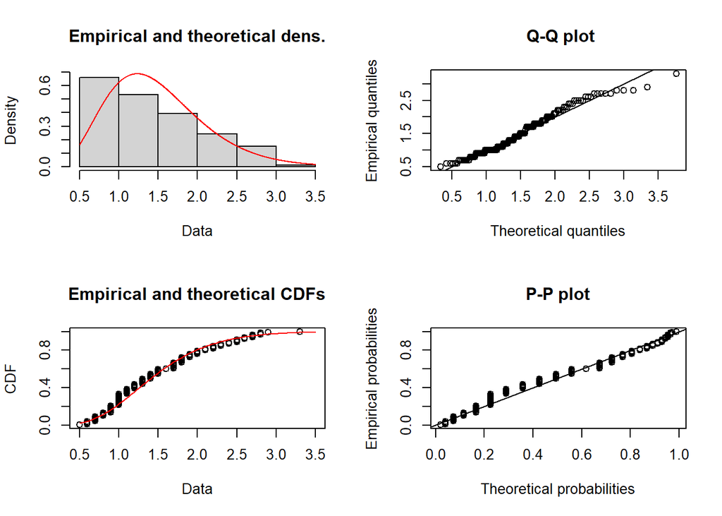

```r
plot(Lima_dist)
```

```r
summary(Lima_dist)
```

```
## Fitting of the distribution ' gamma ' by maximum likelihood
## Parameters :
##       estimate Std. Error
## shape 5.684526  0.6236747
## rate  3.799427  0.4358217
## Loglikelihood:  -140.0094   AIC:  284.0188   BIC:  290.1312
## Correlation matrix:
##           shape      rate
## shape 1.0000000 0.9564738
## rate  0.9564738 1.0000000
```

## Limacina - Tucker Trawl

```r
Lima_dist = fitdist(x_Limacina_TT, "gamma")
length(x_Limacina_TT)
```

```
## [1] 72
```

```r
mean(x_Limacina_TT)
```

```
## [1] 1.236111
```

```r
sd(x_Limacina_TT)
```

```
## [1] 0.2903643
```

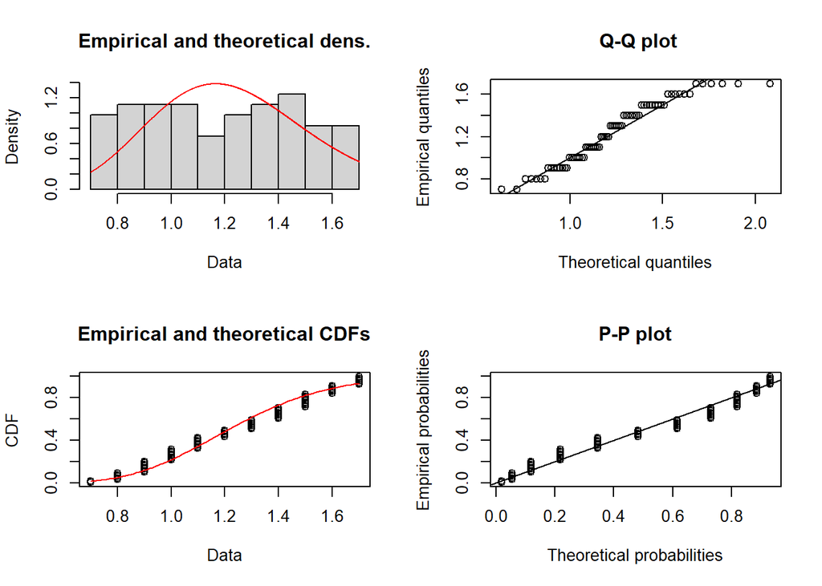

```r
plot(Lima_dist)
```

```r
summary(Lima_dist)
```

```
## Fitting of the distribution ' gamma ' by maximum likelihood
## Parameters :
##       estimate Std. Error
## shape 17.48657   2.887058
## rate  14.14639   2.369372
## Loglikelihood:  -13.02287   AIC:  30.04573   BIC:  34.59906
## Correlation matrix:
##           shape      rate
## shape 1.0000000 0.9857418
## rate  0.9857418 1.0000000
```

## Limacina all angles

Measurements from Multinet length measurements spreadsheet and my tucker trawl measurements and same measurements from the widths size. Divided by 2 for radius for viscous elastic model!

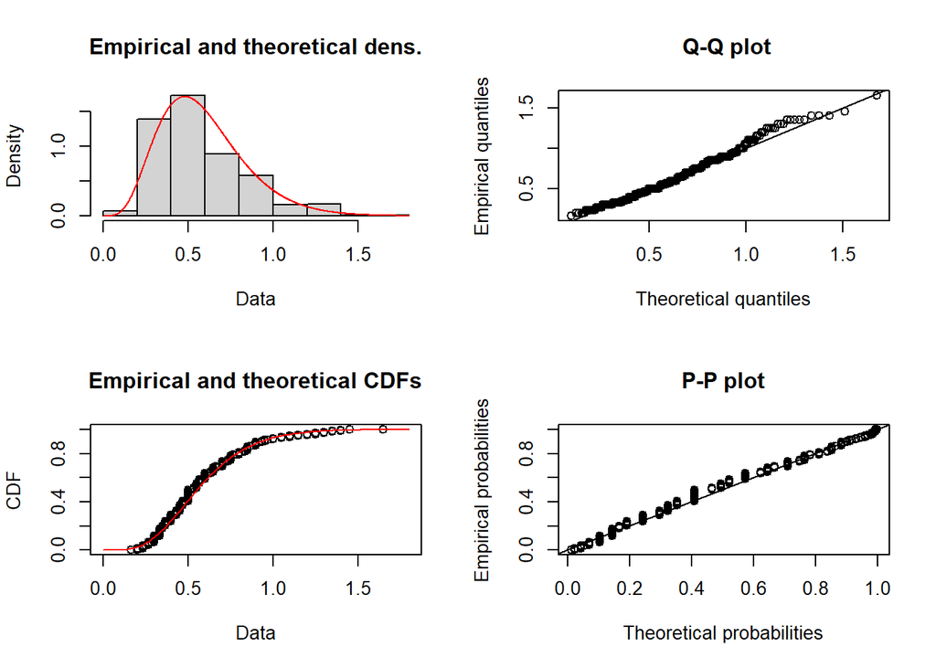

```r
Lima_dist = fitdist(c(x_Limacina_TT, x_Limacina_MN, x_Limacinewidth)/2, "gamma")

plot(Lima_dist)
```

```r
summary(Lima_dist)
```

```
## Fitting of the distribution ' gamma ' by maximum likelihood
## Parameters :
##       estimate Std. Error
## shape 5.402472  0.3465439
## rate  9.167052  0.6162267
## Loglikelihood:  8.178639   AIC:  -12.35728   BIC:  -4.10354
## Correlation matrix:
##           shape      rate
## shape 1.0000000 0.9542339
## rate  0.9542339 1.0000000
```

## Limacina all angles - Full length

```r
Lima_dist = fitdist(c(x_Limacina_TT, x_Limacina_MN), "gamma")
length(c(x_Limacina_TT, x_Limacina_MN))
```

```
## [1] 229
```

```r
mean(c(x_Limacina_TT, x_Limacina_MN))
```

```
## [1] 1.41441
```

```r
sd(c(x_Limacina_TT, x_Limacina_MN))
```

```
## [1] 0.5628968
```

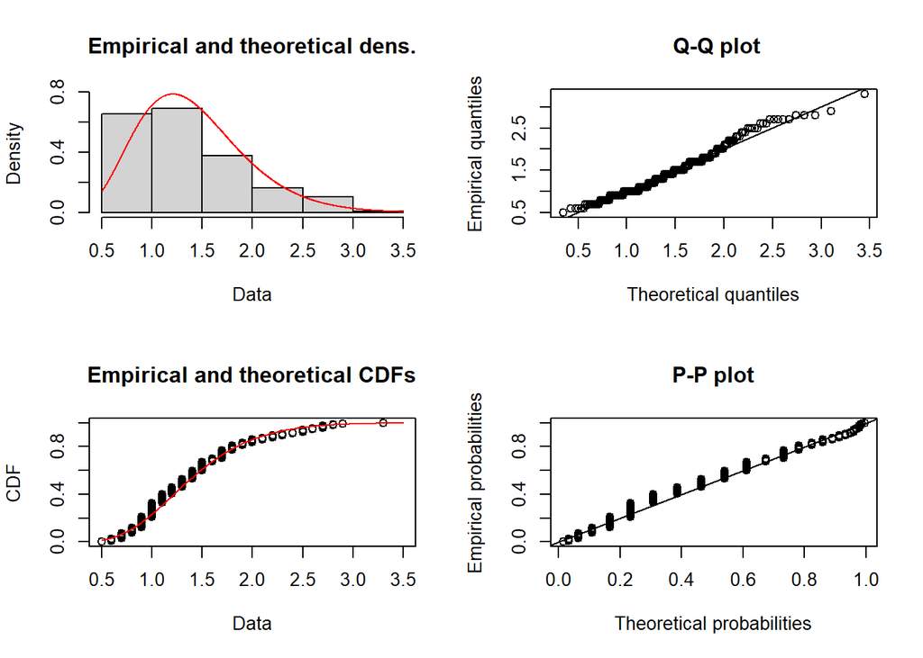

```r
plot(Lima_dist)
```

```r
summary(Lima_dist)
```

```
## Fitting of the distribution ' gamma ' by maximum likelihood
## Parameters :
##       estimate Std. Error
## shape 6.830306  0.6233517
## rate  4.829103  0.4573187
## Loglikelihood:  -172.7456   AIC:  349.4911   BIC:  356.3586
## Correlation matrix:
##           shape      rate
## shape 1.0000000 0.9636968
## rate  0.9636968 1.0000000
```

## Fish Larvae (cod) Tucker measurements

Measurements from tucker trawl because they are smaller and easier to get swimbladder values for. Will find better reason later.

```r
codTuck_dist = fitdist(x_cod_TT, "lnorm")
length(x_cod_TT)
```

```
## [1] 61
```

```r
mean(x_cod_TT)
```

```
## [1] 9.270492
```

```r
sd(x_cod_TT)
```

```
## [1] 3.183412
```

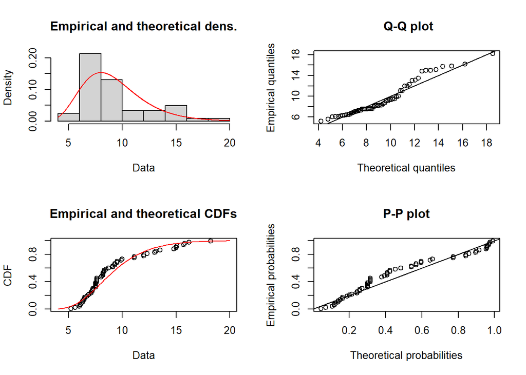

```r
plot(codTuck_dist)
```

```r
summary(codTuck_dist)
```

```
## Fitting of the distribution ' lnorm ' by maximum likelihood
## Parameters :
##          estimate Std. Error
## meanlog 2.1759372 0.03965964
## sdlog   0.3097517 0.02804229
## Loglikelihood:  -147.7964   AIC:  299.5928   BIC:  303.8145
## Correlation matrix:
##         meanlog sdlog
## meanlog       1     0
## sdlog         0     1
```

## Fish Larvae (cod) Multinet measurements

Measurements from Multinet

```r
fish_dist = fitdist(x_fishlarvae_MN, "lnorm")
length(x_fishlarvae_MN)
```

```
## [1] 8
```

```r
mean(x_fishlarvae_MN)
```

```
## [1] 8.275
```

```r
sd(x_fishlarvae_MN)
```

```
## [1] 5.764857
```

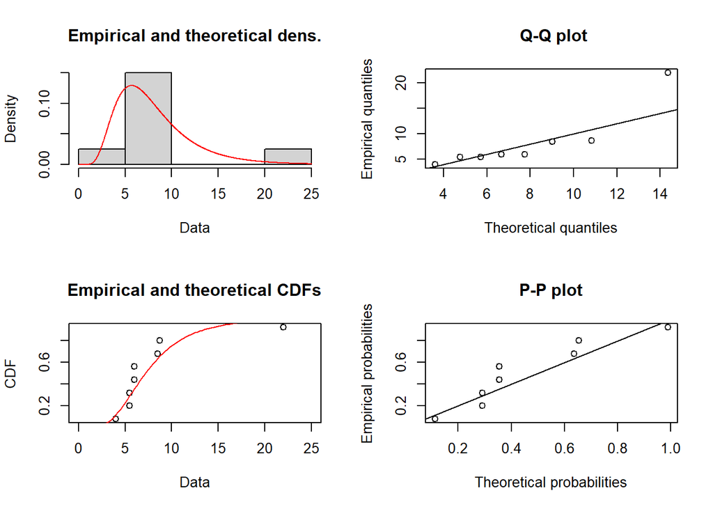

```r
plot(fish_dist)
```

```r
summary(fish_dist)
```

```
## Fitting of the distribution ' lnorm ' by maximum likelihood
## Parameters :
##          estimate Std. Error
## meanlog 1.9717176  0.1708425
## sdlog   0.4832155  0.1208015
## Loglikelihood:  -21.30691   AIC:  46.61382   BIC:  46.7727
## Correlation matrix:
##         meanlog sdlog
## meanlog       1     0
## sdlog         0     1
```

## Fish Larvae (cod) R3 swimbladder

Measurements from tucker trawl because they are smaller and easier to get swimbladder values for. Will find better reason later.

```r
codR3_dist = fitdist(x_codR3, "lnorm")
mean(x_codR3)
```

```
## [1] 0.262459
```

```r
sd(x_codR3)
```

```
## [1] 0.1510805
```

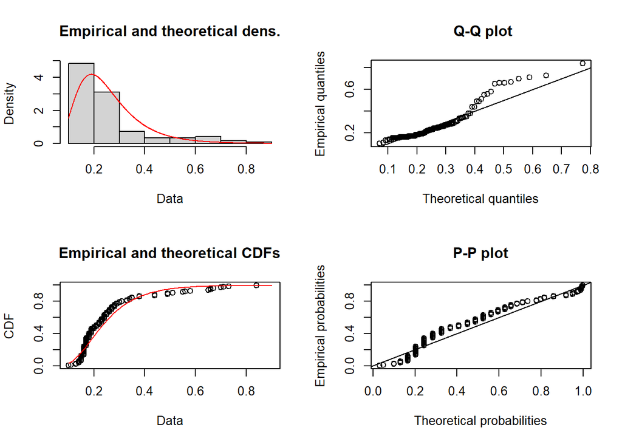

```r
plot(codR3_dist)
```

```r
summary(codR3_dist)
```

```
## Fitting of the distribution ' lnorm ' by maximum likelihood
## Parameters :
##           estimate Std. Error
## meanlog -1.4559927 0.04103930
## sdlog    0.4532939 0.02901854
## Loglikelihood:  101.0488   AIC:  -198.0975   BIC:  -192.4895
## Correlation matrix:
##              meanlog        sdlog
## meanlog 1.000000e+00 4.230929e-12
## sdlog   4.230929e-12 1.000000e+00
```

## Fish Larvae (cod) R2 total radius

Measurements from tucker trawl because they are smaller and easier to get swimbladder values for. Will find better reason later.

```r
codTuck_dist = fitdist(x_codR2, "lnorm")
mean(x_cod_TT)
```

```
## [1] 9.270492
```

```r
sd(x_cod_TT)
```

```
## [1] 3.183412
```

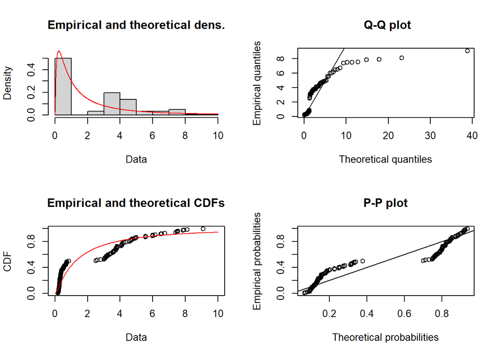

```r
plot(codTuck_dist)
```

```r
summary(codTuck_dist)
```

```
## Fitting of the distribution ' lnorm ' by maximum likelihood
## Parameters :
##          estimate Std. Error
## meanlog 0.2300126  0.1174541
## sdlog   1.2973235  0.0830524
## Loglikelihood:  -232.929   AIC:  469.8581   BIC:  475.4661
## Correlation matrix:
##         meanlog sdlog
## meanlog       1     0
## sdlog         0     1
```

## Fish Larvae (cod) total length

Measurements from tucker trawl adjusted to full length using 8.77R3+1.62 (see ve-cod.ipynb) only length measurements not widths

```r
codTuckLength_dist = fitdist((x_codR3_L*8.77)+(3.24/2), "lnorm")
length((x_codR3_L*8.77)+(3.24/2))
```

```
## [1] 61
```

```r
mean((x_codR3_L*8.77)+(3.24/2))
```

```
## [1] 7.580725
```

```r
sd((x_codR3_L*8.77)+(3.24/2))
```

```
## [1] 3.163891
```

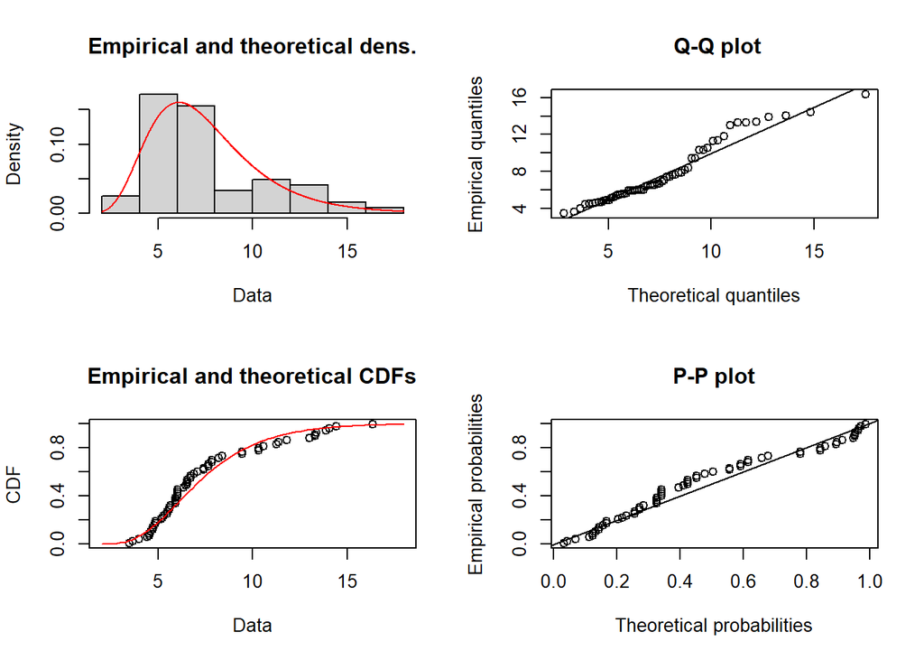

```r
plot(codTuckLength_dist)
```

```r
summary(codTuckLength_dist)
```

```
## Fitting of the distribution ' lnorm ' by maximum likelihood
## Parameters :
##         estimate Std. Error
## meanlog 1.949648 0.04870114
## sdlog   0.380368 0.03443583
## Loglikelihood:  -146.5202   AIC:  297.0404   BIC:  301.2621
## Correlation matrix:
##         meanlog sdlog
## meanlog       1     0
## sdlog         0     1
```

##Copepod

```r
#Density = dnorm(seq(0, 5, by = .01), mean=2.62, sd=0.09)

#dev.new(width=1, height=1)
#plot(seq(0, 5, by = .01),Density,
#     type='l',
#     xlab='Size(mm)')
```